# second week: Introduction to R and Rstudio

Mobile Data

Kimia Hamidieh (95109434)

[figure not shown]

# تمرین سری دوم: تلفن همراه شناسی!

> با استفاده از داده های گوشی های همراه به سوالات زیر پاسخ دهید. برای رسم نمودار از پکیج ggplot2 استفاده کنید.

۱. کدام شرکت بیشترین تعداد گوشی را تولید کرده است؟ نمودار ستونی ۲۰ شرکت برتر بر حسب تعداد گوشی تولید کرده را رسم کنید.

```r
mobile %>% group_by(company) %>%
  summarise(number = n()) %>%
  arrange(desc(number)) %>%
  filter(row_number() <= 20) -> top_companies_stat
print(top_companies_stat$company[1])
```

```
## [1] "Samsung"
```

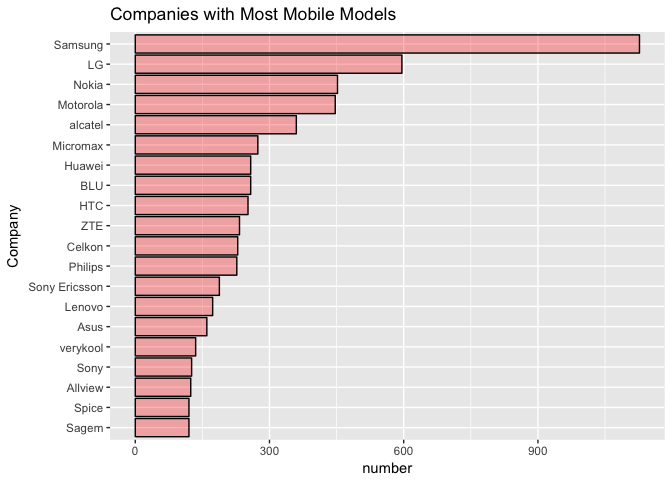

```r
ggplot(data = top_companies_stat, mapping = aes(x = reorder(company, number), y = number)) +
  geom_bar(stat = "identity", color = "black", fill = "red",alpha  = 0.3) + xlab("Company") +
  ggtitle("Companies with Most Mobile Models") + coord_flip()
```

۲. نمودار زمانی طول عرض ضخامت و کیفیت دوربین گوشی ها را بکشید و به نمودار هر یک مدل خطی اضافه کنید.

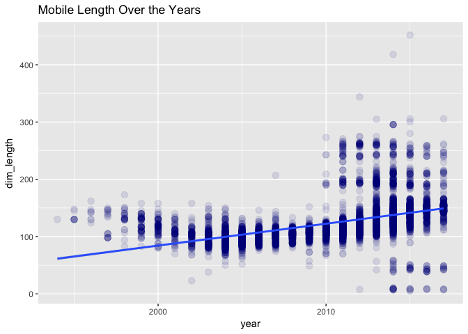

```r
# length - time
ggplot(data = mobile, mapping = aes(x = year, y = dim_length)) +
  geom_point(color = "dark blue", alpha = 0.1, size = 3, na.rm = TRUE) +
  geom_smooth(method = "lm", na.rm = TRUE) +
  ggtitle("Mobile Length Over the Years")
```

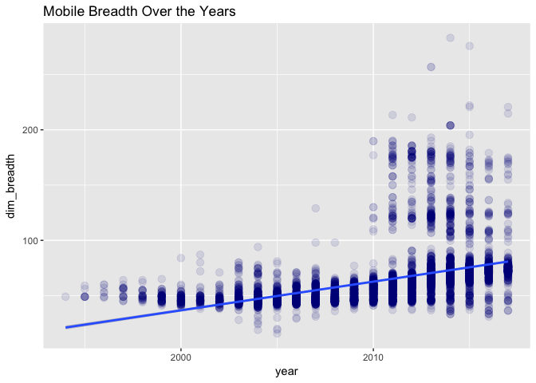

```r
# breadth - time
ggplot(data = mobile, mapping = aes(x = year, y = dim_breadth)) +
  geom_point(color = "dark blue", alpha = 0.1, size = 3, na.rm = TRUE) +
  geom_smooth(method = "lm", na.rm = TRUE) +
  ggtitle("Mobile Breadth Over the Years")
```

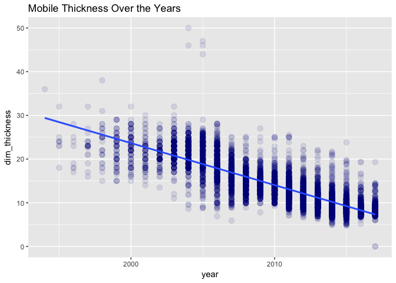

```r
# thickness - time
ggplot(data = mobile, mapping = aes(x = year, y = dim_thickness)) +
  geom_point(color = "dark blue", alpha = 0.1, size = 3, na.rm = TRUE) +
  geom_smooth(method = "lm", na.rm = TRUE) +
  ylim(0, 50) +
  ggtitle("Mobile Thickness Over the Years")
```

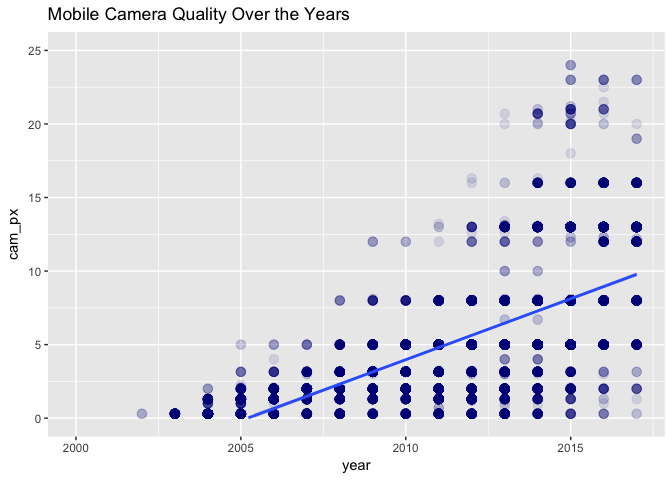

```r
# camera - time
ggplot(data = mobile, mapping = aes(x = year, y = cam_px)) +
  geom_point(color = "dark blue", alpha = 0.1, size = 3, na.rm = TRUE) +
  geom_smooth(method = "lm", na.rm = TRUE) +
  xlim(2000, 2017) +
  ylim(0, 25) +
  ggtitle("Mobile Camera Quality Over the Years")
```

۳. نمودار ستونی متوسط قیمت گوشی بر حسب تعداد سیم کارت و دسترسی به LTE را رسم نمایید.

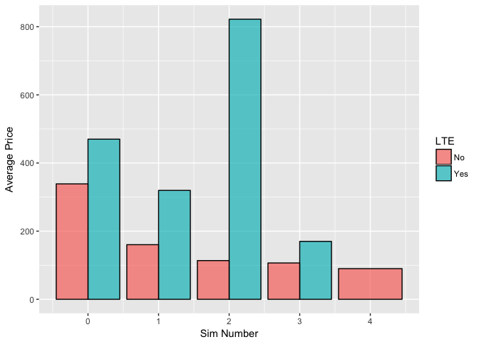

```r
mobile %>% group_by(sim_no, LTE) %>%
  summarise(average = mean(price, na.rm = TRUE)) -> sim_stat

ggplot(data = sim_stat, mapping = aes(x = sim_no, y = average)) +
  geom_bar(aes(fill = LTE), alpha  = 0.7, stat = "identity", position = "dodge", color = "black") +
  xlab("Sim Number") + ylab("Average Price")
```

۴. نمودار جعبه ایی ضحامت گوشی هایی که در سال ۲۰۱۷ معرفی شده اند را برحسب اینکه کمیت جک هدفون رسم نمایید

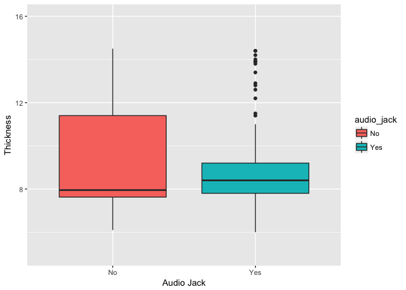

```r
mobile %>% group_by(audio_jack) %>%
  filter(year == 2017) -> thickness_stat

ggplot(data = thickness_stat, mapping = aes(x = audio_jack, y = dim_thickness)) +
  geom_boxplot(aes(fill = audio_jack)) +# coord_flip() +
  ylim(5, 16) +
  xlab("Audio Jack") + ylab("Thickness")
```

۵. مفهوم ppi را در گوشی های موبایل محاسبه و هیستوگرام آن را رسم نمایید. همچنین نمودار سالانه متوسط این کمیت را بکشید. کدام گوشی بیشترین ppi را دارد؟

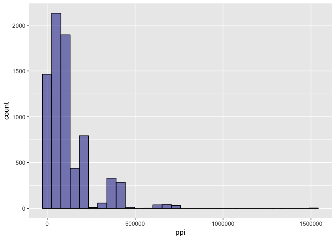

```r
mobile_ppi = cbind(mobile, ppi = (mobile$px_row * mobile$px_col) / mobile$display_size)
ggplot(data = mobile_ppi, aes(ppi)) +
  # xlim(0, 700000) +
  geom_histogram(fill = "dark blue", alpha = 0.5, color = "black")
```

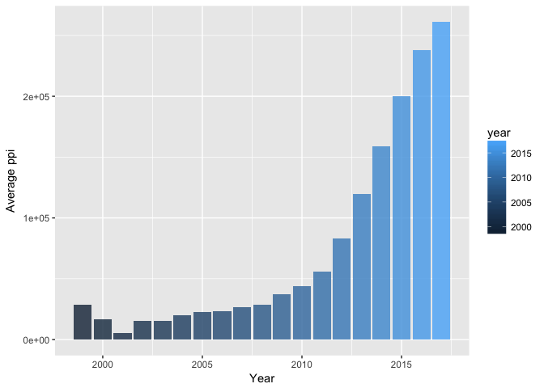

```r
mobile_ppi %>%
  group_by(year) %>%
  summarise(average = mean(ppi, na.rm = TRUE)) -> ppi_stat

ggplot(data = ppi_stat, mapping = aes(x = year, y = average)) +
  geom_bar(aes(fill = year), stat = "identity", alpha = 0.8) +
  xlab("Year") + ylab("Average ppi")
```

۶. در گذشته به بعضی از مدل های گوشی نوکیا **گوشکوب** گفته می شد. سعی کنید برای این مفهوم کمیتی مناسب تعریف کنید . ده گوشکوب برتر را پیدا کرده و نمودار گوشکوبیت آن را رسم نمایید.

```r
mobile %>%
  mutate(gooshkoobiness = 1000 * weight / (dim_thickness * dim_length * dim_breadth) / price + dim_thickness / (dim_length * dim_breadth)) %>%
  filter(dim_thickness > 10) %>%
  filter(is.na(cam_px) | cam_px < 2) %>%
  filter(is.na(card_slot) | card_slot == "No") %>%
  arrange(desc(gooshkoobiness)) %>%
  slice(1:10) -> mobile_gsh
mobile_gsh
```

```
## # A tibble: 10 x 37
##    company  device price  year announced            dim_length dim_breadth
##    <chr>    <chr>  <int> <int> <chr>                     <dbl>       <dbl>
##  1 Nokia    103       10  2012 2012, April               107          45.1
##  2 Micromax X111      20  2010 2010, April. Releas…       88.0        48.0
##  3 Nokia    1202      20  2008 2008, November. Rel…      105          45.0
##  4 Motorola W160      20  2007 2007, October             114          43.0
##  5 Motorola W177      20  2008 2008, April. Releas…      114          42.9
##  6 Vodafone 340       20  2009 2009, November. Rel…      109          45.5
##  7 Nokia    1280      20  2009 2009, November. Rel…      107          45.1
##  8 Nokia    1616      20  2009 2009, November. Rel…      107          45.0
##  9 Samsung  E1110     20  2008 2008, November. Rel…      106          44.0
## 10 LG       KP170     20  2008 2008, December. Rel…      105          45.6
## # ... with 30 more variables: dim_thickness <dbl>, weight <dbl>,
## #   display_tech <chr>, display_size <dbl>, px_row <int>, px_col <int>,
## #   aspect_row <int>, aspect_col <int>, camera <chr>, video <chr>,
## #   cam_px <dbl>, selfie <chr>, sel_px <dbl>, sim_no <int>, os <chr>,
## #   os_type <chr>, card_slot <chr>, chipset <chr>, cpu <chr>, gpu <chr>,
## #   ram <dbl>, LTE <chr>, gps <chr>, radio <chr>, nfc <chr>, wlan <chr>,
## #   audio_jack <chr>, battery_mah <int>, bt_v <dbl>, gooshkoobiness <dbl>
```

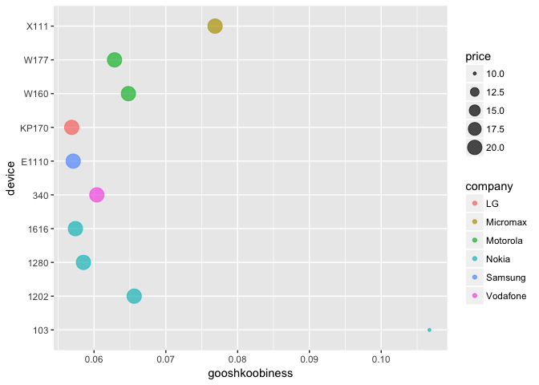

```r
ggplot(data = mobile_gsh, mapping = aes(x = device, y = gooshkoobiness)) +
  geom_point(aes(color = company, size = price), alpha = 0.7) +
  coord_flip()
```

۷. آیا تلفن همراهی وجود دارد که در آب غرق نشود؟ اگر جواب بله هست تمام گوشی های که این خاصیت را دارند بیابید. با کشیدن یک نمودار به این سوال پاسخ دهید.

```r
mobile %>%
  mutate(density = weight * 1000 / (dim_breadth * dim_length * dim_thickness)) -> mobile_dens
floats = mobile_dens[which(mobile_dens$density <= 1), ]
print(floats)
```

```
## # A tibble: 1,014 x 37
##    company device price  year announced           dim_length dim_breadth
##    <chr>   <chr>  <int> <int> <chr>                    <dbl>       <dbl>
##  1 alcatel 2040      30  2014 2014                     123          51.5
##  2 alcatel OT-308    30  2012 2012, February           109          46.0
##  3 alcatel OT-292    NA  2012 2012, February            94.0        45.0
##  4 alcatel OT-228    20  2012 2012, January            106          46.0
##  5 alcatel OT-665    NA  2011 2011, February            96.0        48.0
##  6 alcatel OT-361    NA  2011 2011, February            91.0        44.8
##  7 alcatel OT-223    NA  2010 2010. Released 2010       90.0        44.5
##  8 alcatel OT-217    30  2011 2011, August             106          46.0
##  9 alcatel OT-213    NA  2011 2011, February           108          46.0
## 10 alcatel OT-209    NA  2011 2011, February           108          46.0
## # ... with 1,004 more rows, and 30 more variables: dim_thickness <dbl>,
## #   weight <dbl>, display_tech <chr>, display_size <dbl>, px_row <int>,
## #   px_col <int>, aspect_row <int>, aspect_col <int>, camera <chr>,
## #   video <chr>, cam_px <dbl>, selfie <chr>, sel_px <dbl>, sim_no <int>,
## #   os <chr>, os_type <chr>, card_slot <chr>, chipset <chr>, cpu <chr>,
## #   gpu <chr>, ram <dbl>, LTE <chr>, gps <chr>, radio <chr>, nfc <chr>,
## #   wlan <chr>, audio_jack <chr>, battery_mah <int>, bt_v <dbl>,
## #   density <dbl>
```

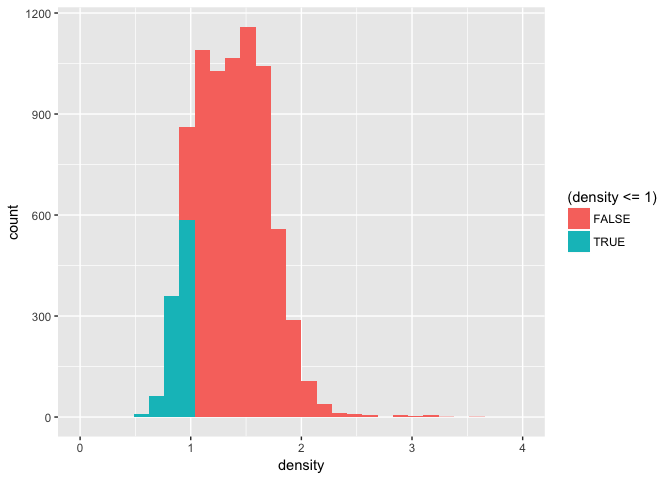

```r
ggplot(data = mobile_dens, aes(density)) +
  geom_histogram(aes(fill = (density <= 1))) +
  xlim(0, 4)
```

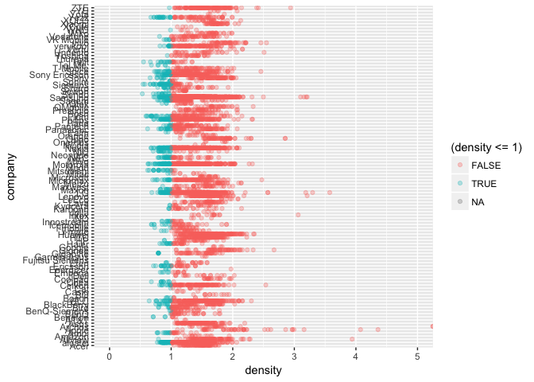

```r
ggplot(data = mobile_dens, aes(y = density, x = company)) +
  geom_point(aes(color = (density <= 1)), alpha = 0.3, na.rm = TRUE) +
  coord_flip() + ylim(0, 5)
```

۸. نمودار پراکنش حجم ذخیره سازی باطری و وزن را رسم نمایید. میزان همبستگی بین این دو کمیت را محاسبه کنید.

```r
cor(x = mobile$battery_mah, y = mobile$weight, use = "complete.obs")
```

```
## [1] 0.8086273
```

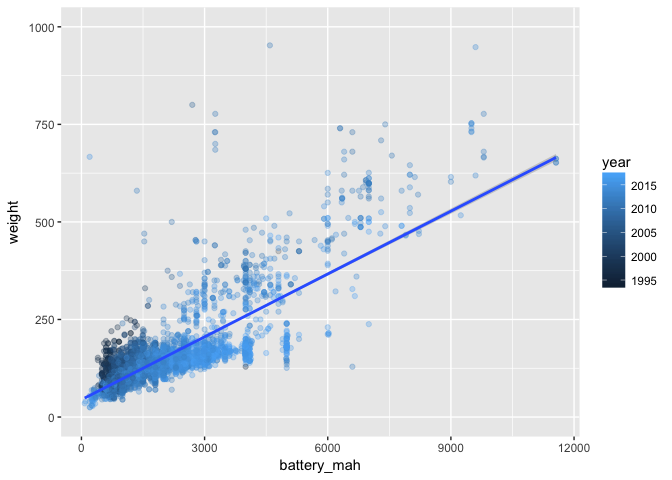

```r
ggplot(data = mobile, mapping = aes(x = battery_mah, y = weight)) +
  geom_point(aes(color = year), alpha = 0.3) +
  geom_smooth(method = "lm", na.rm = TRUE) +
  ylim(0, 1000)
```

۹. قیمت پرچمداران یک برند خاص مثلا سامسونگ را بیابید و نمودار قیمت زمان و نام مدل را رسم نمایید.

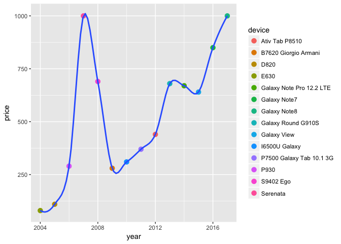

```r
mobile %>%
  filter(company == "Samsung") %>%
  filter(!is.na(year)) %>%
  group_by(year) %>%
  slice(which.max(price)) %>%
  arrange(year) -> ensigns

ggplot(data = ensigns, aes(x = year, y = price)) +
  geom_point(aes(color = device), size = 3) + geom_smooth(span = 0.3)
```

۱۰. سه نمودار جالب رسم کنید و توضیح دهید چرا از نظر شما جالب است؟

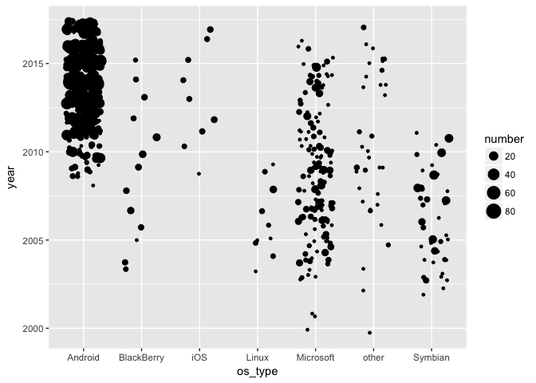

```r
mobile %>%
  filter(!is.na(os_type) & !is.na(year)) %>%
  group_by(os_type) %>%
  summarise(number = n()) %>%
  filter(number > 20) %>%
  select(os_type) -> big_os
big_os = big_os$os_type

mobile %>%
  filter(!is.na(os_type) & !is.na(year)) %>%
  filter(os_type %in% big_os) %>%
  group_by(year, os_type, company) %>%
  summarise(number = n()) -> os_stat #%>%
  # arrange(number)

ggplot(data = os_stat, mapping = aes(x = os_type, y = year)) +
  # geom_jitter(aes(size = number, color = company), width = 0.3)
  geom_jitter(aes(size = number), width = 0.3)
```

```r
## --> full size plot is attached (RPlot1_Q10)
```

[output not shown]

در این نمودار با توجه به sel_px (کیفیت دوربین سلفی) مشخص شده است که چه گوشی هایی از لحاظ ابعاد (و وزن) از نظر کمپانی ها برای سلفی گرفتن (و یا نگه داشتن گوشی در دست) راحت تر و مناسب ترند. با یک نگاه کلی می توان دریافت که گوشی هایی که روی دوربین آن ها هزینه ی زیادی شده است، اکثراً در رنج خاصی از ابعاد طول و عرض و همچنین وزن قرار دارند.

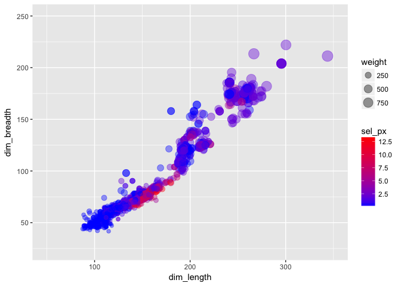

```r
mobile %>%
  filter(!is.na(dim_breadth & !is.na(dim_length))) %>%
  filter(sel_px < 15) -> sel_stat

ggplot(data = sel_stat, mapping = aes(x = dim_length, dim_breadth)) +
  geom_point(aes(color = sel_px, size = weight), alpha = 0.4) +
  ylim(25, 250) + xlim(50, 350) +
  scale_color_gradient(low = "blue", high = "red")
```

این نمودار برای پیدا کردن کمپانی هایی رسم شده است که ابتدا یک آپشن خاص را به گوشی هایشان اضافه کرده و سپس بقیه کمپانی ها نیز به دنبال اضافه کردن آن آپشن می روند. در واقع کمپانی هایی که به اصطلاح یک ترند خاص را شروع کرده اند. اما با توجه به این که داده ها سالیانه جمع آوری شده اند بررسی خیلی دقیق امکان پذیر نیست. در این جا این کم کردن ضخامت موبایل به عنوان ترند در نظر گرفته شده است. که همانطور که در نمودار نشان داده شده است، ابتدا چند کمپانی شروع به کم کردن ضخامت گوشی های خود کرده اند.

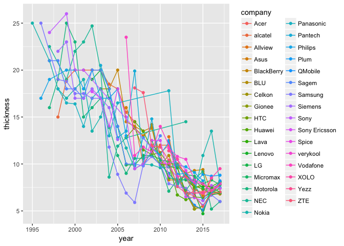

```r
mobile %>%
  filter(!is.na(company) & !is.na(year)) %>%
  group_by(company) %>%
  summarise(number = n()) %>%
  arrange(desc(number)) %>%
  filter(number > 70) -> big_companies
big_companies = big_companies$company

mobile %>%
  filter(!is.na(company) & !is.na(year) & !is.na(dim_thickness)) %>%
  filter(company %in% big_companies) %>%
  group_by(year, company) %>%
  summarise(thickness = min(dim_thickness, na.rm = TRUE)) -> dens_stat

ggplot(data = dens_stat, mapping = aes(x = year, y = thickness, color = company)) +
  geom_point() + geom_line()
```

```r
## --> full size plot is attached (RPlot3_Q10)
```